# LP Brewery

## Probelm Statement

#### Build a report for LP Brewery telling them all the information from their new problem with Dantzig and their previous problem before Dantzig http://learn.codingdojo.com/m/147/6683/49453.

##### Recipes for Hopatronics IPA, American Kolsch, and Barrel-Aged Dantzig

| Beverage | Corn (pounds) | Hops (ounces) | Malt (pounds) |
| --- | --- | --- | --- |
| Hopatronics IPA | 5 | 4 | 35 |
| American Kolsch | 15 | 4 | 20 |
| Dantzig | 10 | 4 | 15 |
| Quantity | 480 | 160 | 1190 |

##### Profit bar chart

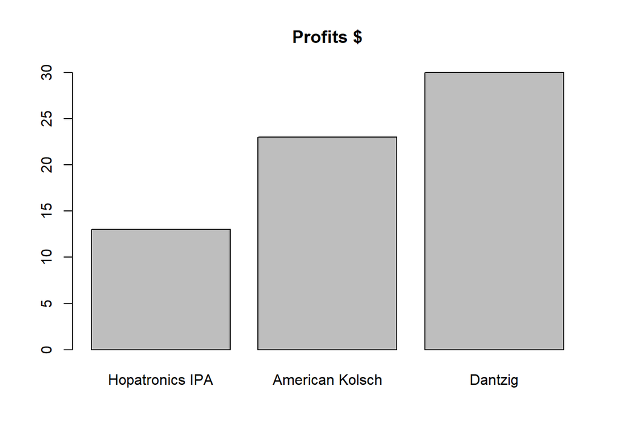

##### Each of the kegs takes the following hours of labor, we have 5 employees full-time

| Beverage | Hours |
| --- | --- |
| Hopatronics IPA | 5 |
| American Kolsch | 10 |
| Dantzig | 20 |
| Total hours of labor | 1200 |

##### Total hours of labor is 1200, which means each employee has to work 8 hour per day for a month

#### How can brewer maximize profits?

##### 1. Before Dantizig

- Plotting the constraints

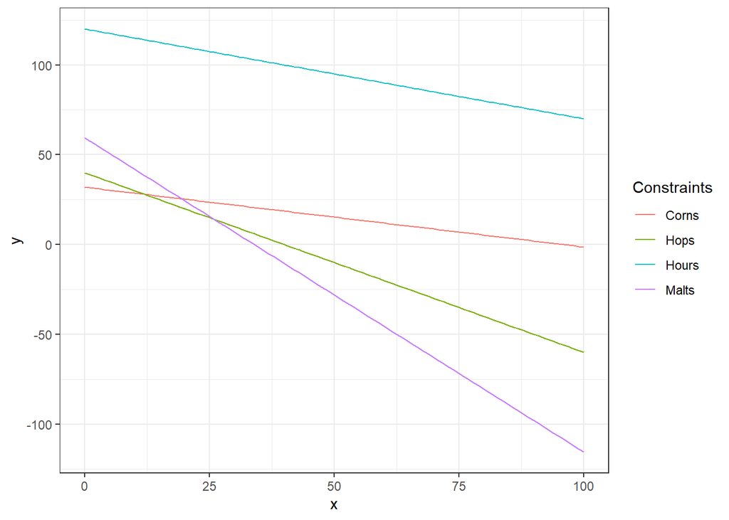

```r
library(ggplot2)
ggplot(data.frame(x = c(0, 100)), aes(x = x)) +
  stat_function(fun = function(x) {(480 - 5*x)/15}, aes(color = "Corns")) +
  stat_function(fun = function(x) {(160 - 4*x)/4 }, aes(color = "Hops")) +
  stat_function(fun = function(x) {(1190 - 35*x)/20 }, aes(color = "Malts")) +
  stat_function(fun = function(x) {(1200 - 5*x)/10 }, aes(color = "Hours")) +
  theme_bw() +
  scale_color_discrete(name = "Constraints")
```

- The optimum value of Hopatronics IPA and American Kolsch to maximize profit

```
## Hopatronics IPA American Kolsch
##              12              28
```

- The maximum profit at optimal point

```
## Total profit: 800
```

- The duals of constraints and reduced costs of variables

```
## [1] 1 2 0 0 0 0
```

- The sensitivity analysis of LP

```
## [1]  3.40e+02  1.28e+02 -1.00e+30 -1.00e+30 -1.00e+30 -1.00e+30
```

```
## [1] 6.000000e+02 1.797647e+02 1.000000e+30 1.000000e+30 1.000000e+30
## [6] 1.000000e+30
```

```
## [1]  7.666667 13.000000
```

```
## [1] 23 39
```

##### 2. After Dantizig

##### After LP Brewery coming up with a hot new brew called The Barrel-Aged Dantzig. They had to think about allocating its personnel to the different manufacturing processes, and the following is an analysis report after adding the new brew.

- The optimum value of Hopatronics IPA and American Kolsch to maximize profit

```
## Hopatronics IPA American Kolsch         Dantzig
##               0               0              40
```

- The maximum profit at optimal point

```
## Total profit: 1200
```

- The duals of constraints and reduced costs of variables

```
## [1]   0.0   7.5   0.0   0.0 -17.0  -7.0   0.0
```

- The sensitivity analysis of LP

```
## [1] -1.000000e+30  2.842171e-14 -1.000000e+30 -1.000000e+30 -1.600000e+01
## [6] -4.000000e+01 -1.000000e+30
```

```
## [1] 1.00e+30 1.92e+02 1.00e+30 1.00e+30 2.95e+01 1.60e+01 1.00e+30
```

```
## [1] -1.0e+30 -1.0e+30  2.3e+01
```

```
## [1] 3e+01 3e+01 1e+30
```